# Logistic Regression in R

## Pima Indians Diabetes Prediction (Cont)

Follow the lab Decision Tree in R this lab will apply the Logistic Regression on the Pima Indians Diabetes dataset. The data exploration, imputation please look at my previous lab, this lab will inherit from that.

### Import dataset

```r
str(data_dib)
```

```
## 'data.frame':    768 obs. of  9 variables:
##  $ Pregnancies             : int  6 1 8 1 NA 5 3 10 2 8 ...
##  $ Glucose                 : int  148 85 183 89 137 116 78 115 197 125 ...
##  $ BloodPressure           : int  72 66 64 66 40 74 50 NA 70 96 ...
##  $ SkinThickness           : int  35 29 NA 23 35 NA 32 NA 45 NA ...
##  $ Insulin                 : int  NA NA NA 94 168 NA 88 NA 543 NA ...
##  $ BMI                     : num  33.6 26.6 23.3 28.1 43.1 25.6 31 35.3 30.5 NA ...
##  $ DiabetesPedigreeFunction: num  0.627 0.351 0.672 0.167 2.288 ...
##  $ Age                     : int  50 31 32 21 33 30 26 29 53 54 ...
##  $ Outcome                 : Factor w/ 2 levels "1","2": 2 1 2 1 2 1 2 1 2 2 ...
```

### Imputation

```r
imputed_data <- mice(data_dib, method = 'pmm', seed = 123)
data_dib_imp <- complete(imputed_data)
```

### Stratified sampling

The sampling will devide 70% instanses of the dataset will go for training and 30% will go for validating

```r
str(training_set)
```

```
## 'data.frame':    538 obs. of  9 variables:
##  $ Pregnancies             : int  6 1 1 6 10 8 4 10 10 5 ...
##  $ Glucose                 : int  148 85 89 137 115 125 110 168 139 166 ...
##  $ BloodPressure           : int  72 66 66 40 70 96 92 74 80 72 ...
##  $ SkinThickness           : int  35 29 23 35 31 32 32 37 41 19 ...
##  $ Insulin                 : int  210 36 94 168 94 205 57 180 29 175 ...
##  $ BMI                     : num  33.6 26.6 28.1 43.1 35.3 40.2 37.6 38 27.1 25.8 ...
##  $ DiabetesPedigreeFunction: num  0.627 0.351 0.167 2.288 0.134 ...
##  $ Age                     : int  50 31 21 33 29 54 30 34 57 51 ...
##  $ Outcome                 : Factor w/ 2 levels "1","2": 2 1 1 2 1 2 1 2 1 2 ...
```

```r
str(test_set)
```

```
## 'data.frame':    230 obs. of  9 variables:
##  $ Pregnancies             : int  8 5 3 2 1 13 1 1 3 8 ...
##  $ Glucose                 : int  183 116 78 197 189 118 103 115 126 99 ...
##  $ BloodPressure           : int  64 74 50 70 60 84 30 70 88 84 ...
##  $ SkinThickness           : int  17 23 32 45 23 47 38 30 41 32 ...
##  $ Insulin                 : int  465 110 88 543 846 230 83 96 235 175 ...
##  $ BMI                     : num  23.3 25.6 31 30.5 30.1 45.8 43.3 34.6 39.3 35.4 ...
##  $ DiabetesPedigreeFunction: num  0.672 0.201 0.248 0.158 0.398 0.551 0.183 0.529 0.704 0.388 ...
##  $ Age                     : int  32 30 26 53 59 31 33 32 27 50 ...
##  $ Outcome                 : Factor w/ 2 levels "1","2": 2 1 2 2 2 2 1 2 1 1 ...
```

The proposion of the prediction variable in training set and test set:

```r
prop.table(table(training_set$Outcome))
```

```
##
##         1         2
## 0.6505576 0.3494424
```

```r
prop.table(table(test_set$Outcome))
```

```
##
##         1         2
## 0.6521739 0.3478261
```

### Default Logistic Regression Traing

```r
classifier = glm(Outcome ~.,training_set, family = binomial)
summary(classifier)
```

```
##
## Call:
## glm(formula = Outcome ~ ., family = binomial, data = training_set)
##
## Deviance Residuals:
##     Min       1Q   Median       3Q      Max
## -2.6593  -0.6760  -0.3725   0.6562   2.2061
##
## Coefficients:
##                            Estimate Std. Error z value Pr(>|z|)
## (Intercept)              -9.2278791  0.9833702  -9.384  < 2e-16 ***
## Pregnancies               0.1412872  0.0433058   3.263   0.0011 **
## Glucose                   0.0405022  0.0051572   7.854 4.04e-15 ***
## BloodPressure            -0.0170690  0.0104870  -1.628   0.1036
## SkinThickness             0.0054744  0.0157864   0.347   0.7288
## Insulin                  -0.0003942  0.0013053  -0.302   0.7627
## BMI                       0.0983819  0.0249676   3.940 8.14e-05 ***
## DiabetesPedigreeFunction  0.5952212  0.3806996   1.563   0.1179
## Age                       0.0150918  0.0118149   1.277   0.2015
## ---
## Signif. codes:  0 '***' 0.001 '**' 0.01 '*' 0.05 '.' 0.1 ' ' 1
##
## (Dispersion parameter for binomial family taken to be 1)
##
##     Null deviance: 696.28  on 537  degrees of freedom
## Residual deviance: 477.19  on 529  degrees of freedom
## AIC: 495.19
##
## Number of Fisher Scoring iterations: 5
```

3 significant features are: Glucose, BMI and Pregnancies

### Logistic Regression Training With Significant Features Only

As mention below there are 3 significant features: Glucose, BMI and Pregnancies, this classfier will base only on those 3 features.

```r
classifier_sig = glm(Outcome ~ Glucose+BMI+Pregnancies,training_set, family = binomial)
summary(classifier_sig)
```

```
##
## Call:
## glm(formula = Outcome ~ Glucose + BMI + Pregnancies, family = binomial,
##     data = training_set)
##
## Deviance Residuals:
##     Min       1Q   Median       3Q      Max
## -2.3438  -0.6673  -0.3805   0.6640   2.2988
##
## Coefficients:
##              Estimate Std. Error z value Pr(>|z|)
## (Intercept) -9.485274   0.860441 -11.024  < 2e-16 ***
## Glucose      0.040321   0.004303   9.371  < 2e-16 ***
## BMI          0.094032   0.018240   5.155 2.53e-07 ***
## Pregnancies  0.158409   0.036260   4.369 1.25e-05 ***
## ---
## Signif. codes:  0 '***' 0.001 '**' 0.01 '*' 0.05 '.' 0.1 ' ' 1
##
## (Dispersion parameter for binomial family taken to be 1)
##
##     Null deviance: 696.28  on 537  degrees of freedom
## Residual deviance: 483.90  on 534  degrees of freedom
## AIC: 491.9
##
## Number of Fisher Scoring iterations: 5
```

AIC now is 491.9 lower than 495.19 of the previous classifier.

### Logistic Regression Training With Significant Features Only and Scaling

```r
training_set[ ,1:8] = scale(training_set[ , 1:8])
classifier_sca = glm(Outcome ~ Glucose+BMI+Pregnancies,training_set, family = binomial)
summary(classifier_sca)
```

```
##
## Call:
## glm(formula = Outcome ~ Glucose + BMI + Pregnancies, family = binomial,
##     data = training_set)
##
## Deviance Residuals:
##     Min       1Q   Median       3Q      Max
## -2.3438  -0.6673  -0.3805   0.6640   2.2988
##
## Coefficients:
##             Estimate Std. Error z value Pr(>|z|)
## (Intercept)  -0.8754     0.1180  -7.418 1.19e-13 ***
## Glucose       1.2439     0.1327   9.371  < 2e-16 ***
## BMI           0.6469     0.1255   5.155 2.53e-07 ***
## Pregnancies   0.4933     0.1129   4.369 1.25e-05 ***
## ---
## Signif. codes:  0 '***' 0.001 '**' 0.01 '*' 0.05 '.' 0.1 ' ' 1
##
## (Dispersion parameter for binomial family taken to be 1)
##
##     Null deviance: 696.28  on 537  degrees of freedom
## Residual deviance: 483.90  on 534  degrees of freedom
## AIC: 491.9
##
## Number of Fisher Scoring iterations: 5
```

AIC value keep same as Logistic Regression Training With Significant Features Only, but the coefficients of each varible is little bit different.

### Preditction Result

```r
pred = predict(classifier, type = 'response', test_set[ ,-9] )
pred = ifelse(pred > 0.5, 1, 0)
pred_sig = predict(classifier_sig, type = 'response', test_set[ ,-9] )
pred_sig = ifelse(pred_sig > 0.5, 1, 0)
pred_sca = predict(classifier_sca, type = 'response', test_set[ ,-9] )
pred_sca = ifelse(pred_sca > 0.5, 1, 0)
cm = table(test_set$Outcome, pred)
cm_sig = table(test_set$Outcome, pred_sig)
cm_sca = table(test_set$Outcome, pred_sca)
```

The accuracy of 3 models above on training set and test set:

| Default Logistic Regression Traing Accuracy on training set | Default Logistic Regression Traing Accuracy on test set | Logistic Regression Training With Significant Features Only Accuracy on training set | Logistic Regression Training With Significant Features Only Accuracy on test set | Logistic Regression Training With Significant Features Only and Scaling Accuracy on training set | Logistic Regression Training With Significant Features Only and Scaling Accuracy on test set |
| --- | --- | --- | --- | --- | --- |
| 0.6505576 | 0.7652174 | 0.6505576 | 0.7608696 | 0.7713755 | 0.6521739 |

The Logistic Regression Training With Significant Features Only and Scaling seems become overfitting the distance between the accuracy on training set and on test set is far away, it leads to the the accuracy on the test set lowest among 3 models. The ROC curve of 3 models on test set

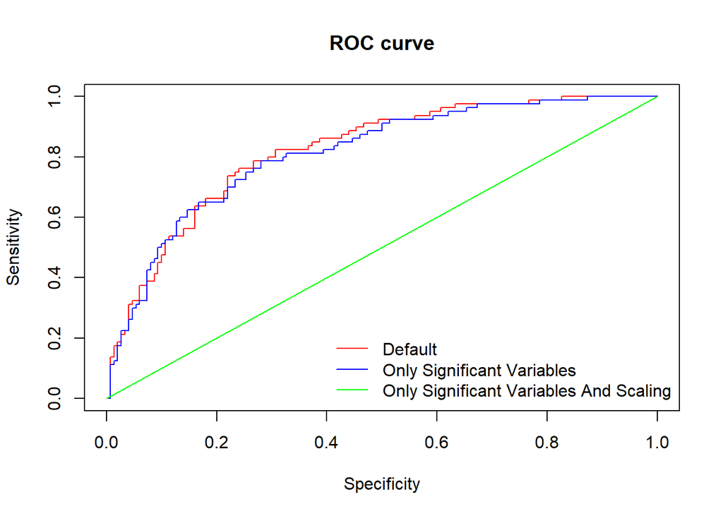

```r
plot(perf,
     main = "ROC curve",
     ylab = "Sensitivity",
     xlab = "Specificity", col = "red")
plot(perf_sig, add = TRUE, col = "blue")
plot(perf_sca, add = TRUE, col = "green")
legend("bottomright", c("Default", "Only Significant Variables", "Only Significant Variables And Scaling"), lty=1,
    col = c("red", "blue","green"), bty="n")
```

The AUC summary table of 3 models:

| Default Logistic Regression Traing | Logistic Regression Training With Significant Features Only | Logistic Regression Training With Significant Features Only and Scaling |
| --- | --- | --- |
| 0.822 | 0.813 | 0.5 |

The Default Logistic Regression model show outperform between 3 models with the highest AUC, which also a reason it has the highest accuracy. The second rank is belong to Logistic Regression With Significant Features Only model with the AUC value slightly lower than Default Logistic Regression. The AUC of Logistic Regression Training With Significant Features Only and Scaling is 0.5 can be said like toss a coint.

### Prediction Result In Decision Tree

The prediction accuracy of the 4 models based on Decision Tree:

| Default Parameter Decision Tree | Decision Tree using Information Gain index | Decision Tree using Entropy index | Parameter Decision Tree |
| --- | --- | --- | --- |
| 0.6956522 | 0.6913043 | 0.6956522 | 0.7043478 |

### Prediction Result In Naïve Bayes

The prediction accuracy of the 3 models based on Naïve Bayes:

| Default Naïve Bayes | Naïve Bayes using Laplace | Naïve Bayes using Kernel |
| --- | --- | --- |
| 0.7652174 | 0.7652174 | 0.7913043 |

### Conclusion

The accuracy of the best Logistic Regression model higher than the best model based on Decision Tree, but still behind the highest model based on Naïve Bayes.